# Monitoramento Programa UPA 24h

21 de outubro de 2018

## MONITORAMENTO DO PROGRAMA UPA 24h NO BRASIL - 1º SEMESTRE DE 2018

A UPA 24h é um estabelecimento de saúde que compõe a Rede de Atenção às Urgências. É de complexidade intermediária, e deve atuar em conjunto com a Atenção Básica e o SAMU 192 de um lado, e a Atenção Hospitalar e a Atenção Domiciliar de outro. Iniciado pelo Ministério da Saúde em 2008, o Programa UPA 24h incentiva a construção e implantação de UPA, visa melhorar os serviços de urgência e reduzir a superlotação dos hospitais. A implantação é prevista para municípios de no mínimo 50.000 habitantes, com atendimento regionalizado. As UPA têm sua estrutura física e de atendimento classificada em Portes:

- Porte I - De 50.000 a 100.000 habitantes
- Porte II - 100.001 a 200.000
- Porte III - 200.001 a 300.000 habitantes

[output not shown]

[output not shown]

[output not shown]

[figure not shown]

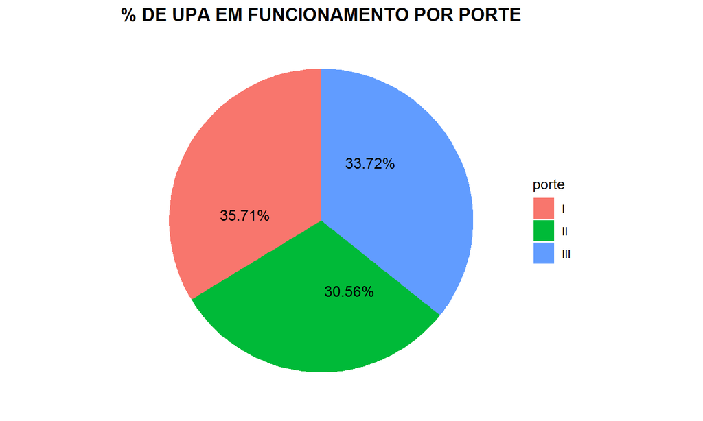

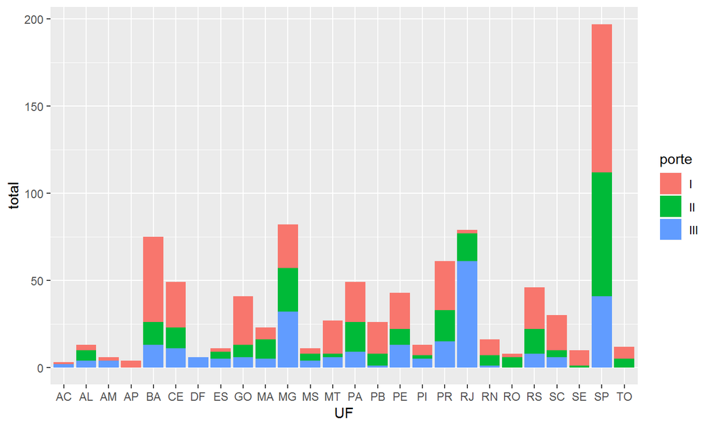

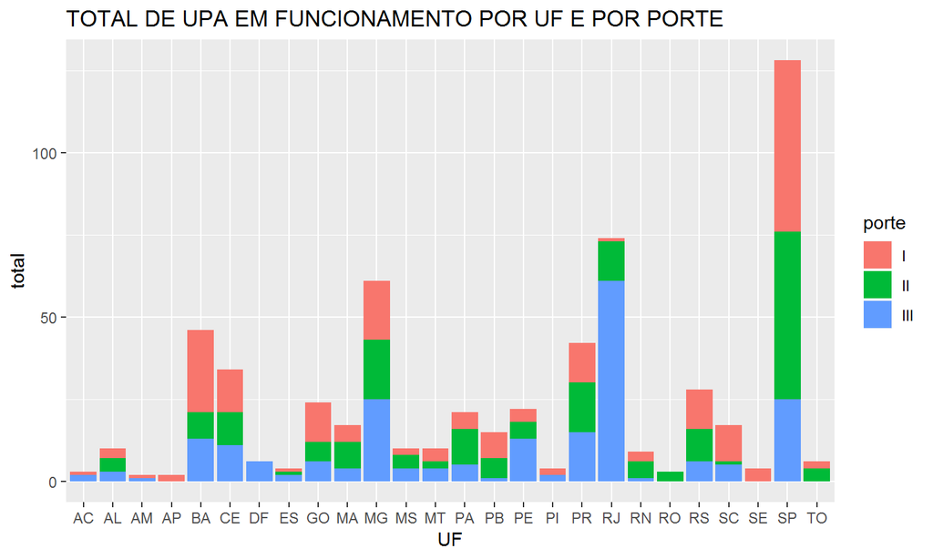

```
## # A tibble: 6 x 10
## # Groups:   CNES, UF, MUNIC, OPCAO_CUSTEIO [6]
##    CNES UF    MUNIC OPCAO_CUSTEIO `201801` `201802` `201803` `201804`
##   <dbl> <chr> <chr> <chr>            <dbl>    <dbl>    <dbl>    <dbl>
## 1  4340 BA    Salv~ VIII             56766    56351    64461    55789
## 2  4774 BA    Salv~ VIII             38902    30095    50596    44606
## 3  9296 SP    São ~ V                27780    38727    64095    44014
## 4 10049 MS    Camp~ VIII             25291    23341    32016    30552
## 5 10057 MS    Camp~ V                27493    27613    34093    32872
## 6 10081 MS    Camp~ V                21010    22767    31603    29647
## # ... with 2 more variables: `201805` <dbl>, `201806` <dbl>
```

```
## # A tibble: 6 x 19
##   UF    progr codIBGE municipio porte nrproposta valor_total_UPA
##   <chr> <chr>   <dbl> <chr>     <chr> <chr>                <dbl>
## 1 AP    2009   160030 Macapá    I     23086.176~         1400000
## 2 BA    2010   290650 Candeias  I     13830.336~         1400000
## 3 BA    2013~  292150 Monte Sa~ I     11481.390~         2200000
## 4 BA    2010   292700 Rio Real  I     15088.800~         1400000
## 5 CE    2013~  230440 Fortaleza III   11621.453~         4000000
## 6 CE    2008~  230765 Maracanaú II    076058500~         1500000
## # ... with 12 more variables: Data1aParcela <dttm>, Data_OIS <dttm>,
## #   data_conclusao <dttm>, Status_UPA <chr>, ano_habil_construcao <chr>,
## #   CNES <dbl>, Nome_UPA <chr>, Data_inauguracao <dttm>,
## #   status_custeio <chr>, Ano_funcionamento <dbl>, Opcao_custeio <chr>,
## #   situacao <chr>
```

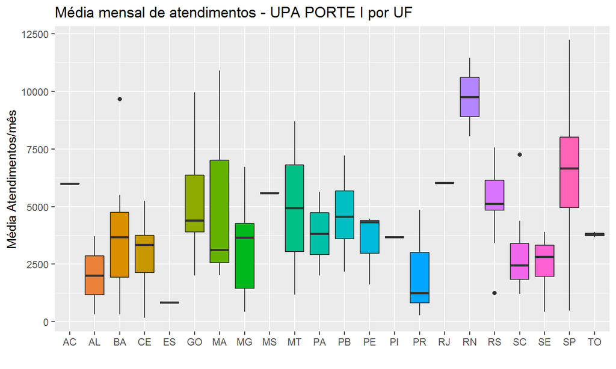

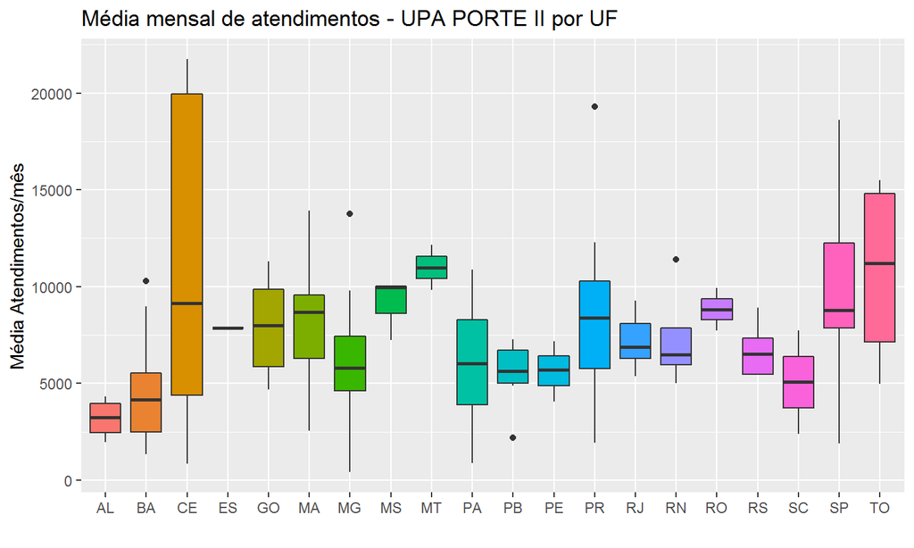

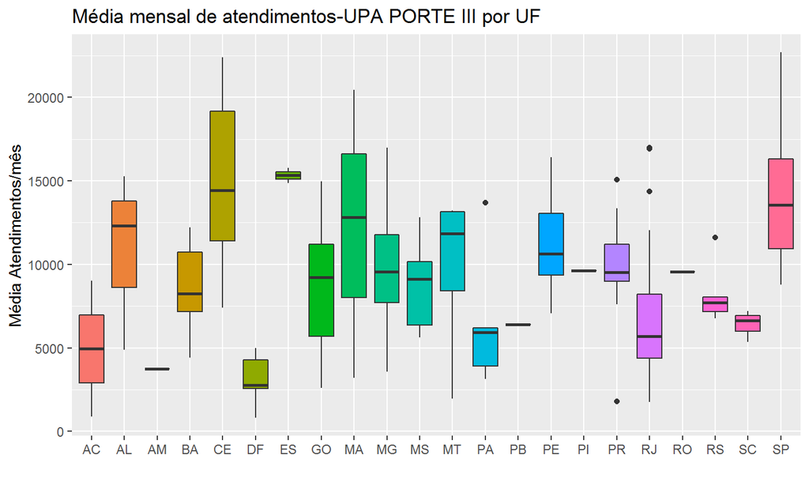

## UPA POR PORTE

[figure not shown]

## UPA POR PORTE NOS ESTADOS

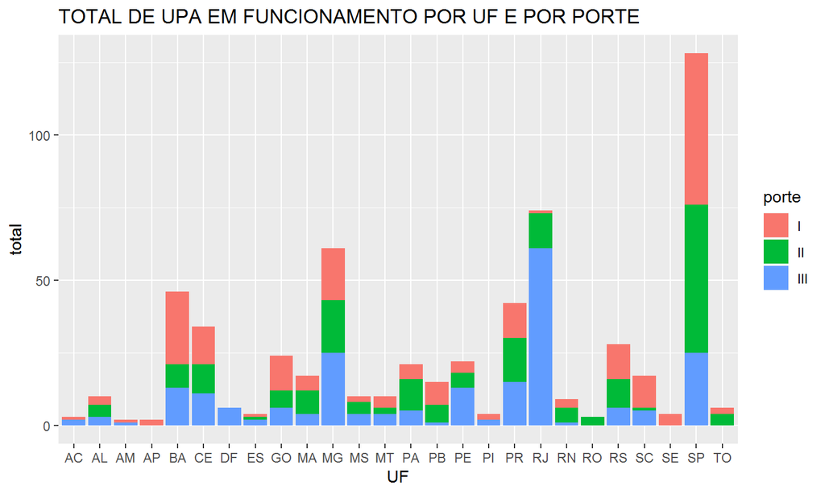

## PRODUÇÃO DAS UPA

Considerando o total das UPA já funcionando por opção de capacidade de atendimento, temos uma média de atendimentos esperados, que seriam em torno de 4.500/mês nas unidades Porte I, 6.750 nas Porte II, e 10.125 nas Porte III. A seguir gráficos da média mensal de atendimentos realizados nas UPA por porte. Dados do 1º semestre de 2018.

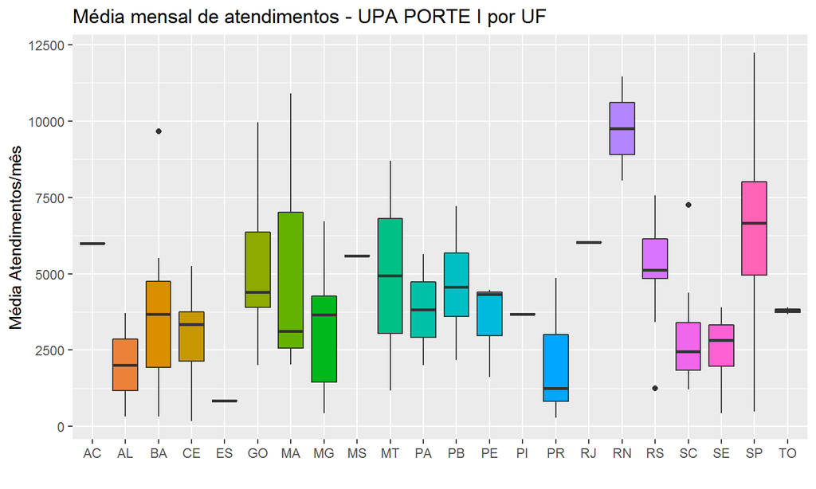

## PRODUÇÃO DAS UPA DISTRIBUIÇÃO POR ESTADOS

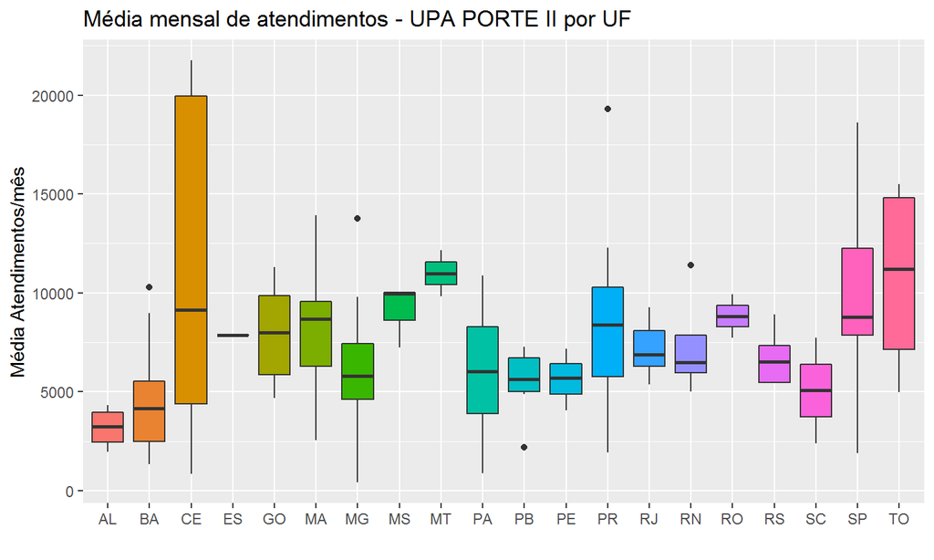

## PRODUÇÃO DAS UPA DISTRIBUIÇÃO POR ESTADOS

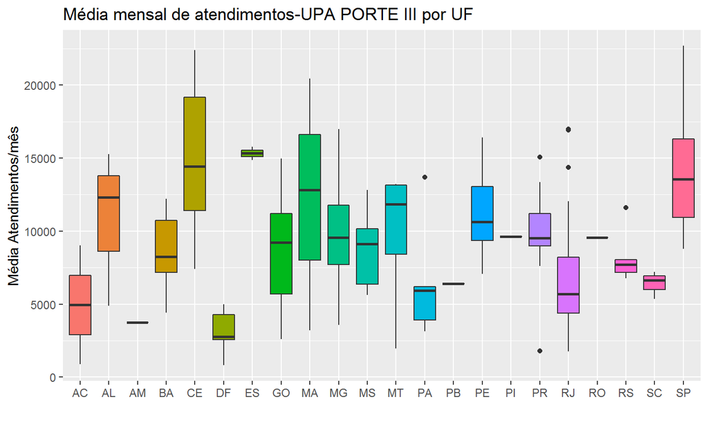